# ML_coursework_part1_v1

## Machine Learning Coursework (Part 1)

For the coursework, please make sure to implement your own code and not use libraries (except where explicitly asked). You will need to present your own code that performs nested cross-validation and the k-nearest neighbour algorithm, build confusion matrices, and estimate distances between data samples.

The purpose of this coursework is to help you:

- Get familiar with **common python modules / functions** used for ML in python
- Get practical experience **implementing** ML methods in python
- Get practical experience regarding **parameter selection** for ML methods
- Get practical experience on **evaluating** ML methods and applying cross-validation

Notes:

- don't use libraries that implement kNN or cross-validation. We want to see your code!
- Remember to comment all of your code (see here for tips: https://stackabuse.com/commenting-python-code/). You can also make use of Jupyter Markdown, where appropriate, to improve the layout of your code and documentation.
- Please add docstrings to all of your functions (so that users can get information on inputs/outputs and what each function does by typing SHIFT+TAB over the function name. For more detail on python docstrings, see here: https://numpydoc.readthedocs.io/en/latest/format.html)
- When a question allows a free-form answer (e.g. what do you observe?), create a new markdown cell below and answer the question in the notebook.
- Always save your notebook when you are done (this is not automatic)!
- Upload your completed notebook using the VLE

Plagiarism: please make sure that the material you submit has been created by you. Any sources you use for code should be properly referenced. Your code will be checked for plagiarism using appropriate software.

### Marking

The grades in this coursework are allocated approximately as follows:

|  | mark |
| --- | --- |
| Data exploration (+ 2 questions) | 10 |
| Code, docu. & comments (KNN + Evaluation + NCV) | 10 |
| Results (KNN folds + Summary + Confusion matrices) | 10 |
| Final questions: | 10 |
| Overall quality & use of Markdown | 10 |
| Total available | **50** |

## 1. Exploratory Data Analysis

In this coursework we are going to be working with the **Wine** dataset. This is a 178 sample dataset that categorises 3 different types of Italian wine using 13 different features. The code below loads the Wine dataset and selects a subset of features for you to work with.

```python
# set matplotlib backend to inline
%matplotlib inline

# import modules
from sklearn import datasets
import numpy as np
import matplotlib.pyplot as plt
import pandas as pd

# load data
wine=datasets.load_wine()
#print(wine.DESCR)

# this dataset has 13 features, we will only choose a subset of these
df_wine = pd.DataFrame(wine.data, columns = wine.feature_names )
selected_features = ['alcohol','flavanoids','color_intensity','ash']

# extract the data as numpy arrays of features, X, and target, y
X = df_wine[selected_features].values
y = wine.target
```

### 1.1. Visualising the data

The first part of tackling any ML problem is visualising the data in order to understand some of the properties of the problem at hand. When there are only a small number of classes and features, it is possible to use scatter plots to visualise interactions between different pairings of features.

The following image shows what such a visualisation might look like on the Iris dataset that you worked on during the Topic exercises.

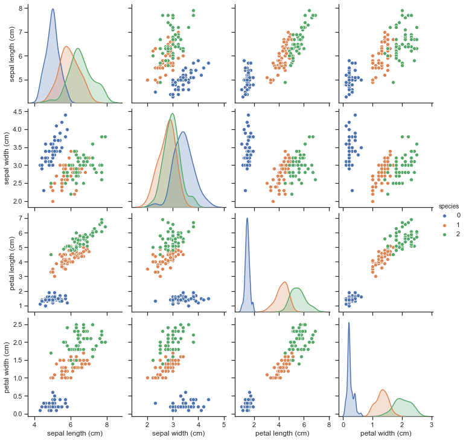

Your first task is to recreate a similar grid for the **Wine** dataset, with each off-diagonal subplot showing the interaction between two features, and each of the classes represented as a different colour. The on-diagonal subplots (representing a single feature) should show a distribution (or histogram) for that feature.

You should create a function that, given data X and labels y, plots this grid. The function should be invoked something like this:

```
myplotGrid(X,y,...)
```

where X is your training data and y are the labels (you may also supply additional optional arguments). You can use an appropriate library to help you create the visualisation. You might want to code it yourself using matplotlib functions scatter and hist - however, this is not strictly necessary here, so try not spend too much time on this.

```python
# define plotting function

import seaborn as sns

def myplotGrid(X, y, selected_features):
    """
    Plot interactions and distributions of features X by wine type.

    Parameters
    ----------
    X : ndarray
    (n, d) NumPy array contains n datapoints with d features.

    y : ndarray
    (n, ) NumPy array contains labels for n datapoints.

    selected_features : list of str
    A list of features' name.

    """
    # create a data frame that combins X and y
    df_X_and_y = pd.DataFrame(X, columns=selected_features)
    df_X_and_y['wine_type'] = y

    # plot grid
    sns.pairplot(df_X_and_y, hue='wine_type')
    plt.show()
```

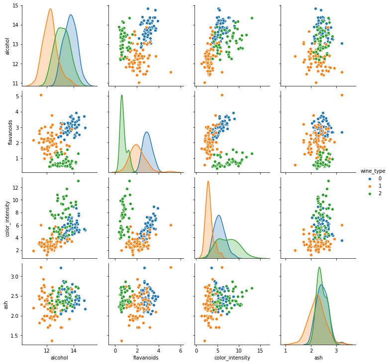

```python
# run the plotting function
myplotGrid(X, y, selected_features)
```

### 1.2. Exploratory Data Analysis under noise

When data are collected under real-world settings they usually contain some amount of noise that makes classification more challenging. In the cell below, invoke your exploratory data analysis function above on a noisy version of your data X.

Try to perturb your data with some Gaussian noise,

```
# initialize random seed to replicate results over different runs
mySeed = 12345
np.random.seed(mySeed)
XN=X+np.random.normal(0,0.6,X.shape)
```

and then invoke

```
myplotGrid(XN,y)
```

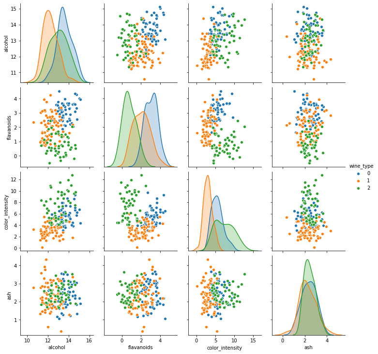

```python
# noise code
# initialize random seed to replicate results over different runs
mySeed = 12345
np.random.seed(mySeed)
XN=X+np.random.normal(0,0.6,X.shape)
myplotGrid(XN, y, selected_features)
```

### Q1. Exploratory data analysis

Based on your exploratory analysis, if you were to build a classifier using only two of the available features, which ones would you choose and why? Answer as fully as you can.

answer: I would use flavanoids and color_intensity because they have different distributions to distinguish each label. Seeing the on-diagonal distributions of flavanoids and color_intensity in both grid, the original ones and the ones with some Gaussian noise, we can see that they are more differentiable than the distributions of ash and alcohol. For example, flavanoids and color_intensity have different means and variances while ash and alcohol are centered around similar means and have similar spread. We can see this characteristics in both grids.

Also, seeing the scatterplots of flavanoids versus color_intensity, we can see that each data point is scattered in three separated clusters and easy to classify while other combinations have mixture of data points which makes harder to classify.

### Q2. Data with noise

What do you observe by plotting the data without noise compared to plotting with added Gaussian noise?

## 2. Implementing kNN

In the cell below, develop your own code for performing k-Nearest Neighbour classification. You may use the scikit-learn k-NN implementation from the labs as a guide - and as a way of verifying your results - but it is important that your implementation does not use any libraries other than the basic numpy and matplotlib functions.

Define a function that performs k-NN given a set of data. Your function should be invoked similary to:

```
    y_ = mykNN(X,y,X_,options)
```

where X is your training data, y is your training outputs, X_ are your testing data and y_ are your predicted outputs for X_. The options argument (can be a list or a set of separate arguments depending on how you choose to implement the function) should at least contain the number of neighbours to consider as well as the distance function employed.

Hint: it helps to break the problem into various sub-problems, implemented as helper function. For example, you might want to implement separate function(s) for calculating the distances between two vectors. And another function that uncovers the nearest neighbour(s) to a given vector.

```python
# helper code

def get_distance_with_y(Xi_, X, y, metric):
    """
    Get the distance list from Xi to every data point in X, along with y.

    Parameters
    ----------
    Xi_ : list
    A list of a single datapoints with d features.

    X : ndarray
    (n, d) NumPy array contains n datapoints with d features.

    y : ndarray
    (n, ) NumPy array contains labels for n datapoints.

    metric : str
    Distance measure.

    Return
    ----------
    (n, d) NumPy array
    contains n datapoints with 2 features (distance, label).

    """
    distance_with_y = np.zeros((X.shape[0], 2), dtype = object)
    i = 0
    for Xi, yi in zip(X, y):

        # calculate distance with given metric
        if(metric == 'euclidean'):
            distance = np.linalg.norm(Xi_ - Xi, ord=2)
        elif(metric == 'manhattan'):
            distance = np.linalg.norm(Xi_ - Xi, ord=1)
        else:
            raise ValueError("The value of metric is "
                              "supposed to be euclidean or manhattan, got "
                              "{}.".format(metric))
        distance_with_y[i][0] = distance
        distance_with_y[i][1] = int(yi)
        i+=1

    return distance_with_y


def predict(n_nearest_neighbors, prob_table):
    """
    Predict the most frequent class from n_th nearest neighbors.

    Parameters
    ----------
    n_nearest_neighbors : ndarray
    (n, 2) NumPy array contains n neighbors with 2 columns, distance and class.

    Return
    ----------
    int
    The label number.

    """
    # access 2nd column of classes and count frequency
    classes = [int(label) for label in n_nearest_neighbors[:,1]]
    count = np.bincount(classes)

    # if k is even and the frequency counts are same
    if len(n_nearest_neighbors)%2==0 and is_same_count(count):

        # predict the label based on probability
        max_prob = 0.0
        for c in np.unique(classes):
            if prob_table[c] > max_prob:
                max_prob = prob_table[c]
                label = c
    else:
        # otherwise choose the most frequent label
        label = int(np.argmax(count))

    return label

def is_same_count(count):
    """
    Check if frequency count is same.

    Parameters
    ----------
    count : list
    A list bin count of classes.

    Return
    ----------
    True
    If frequency count is same.
    False
    If frequency count is not same.

    """
    # remove 0s from bin counts
    count2 = [i for i in count if i != 0]

    # check if all counts are same
    return all(x == count2[0] for x in count2)


def bulld_prob_table(y):
    """
    Build probability table.

    Parameters
    ----------
    y : list
    A list of classes.

    Return
    ----------
    dict
    A dictionary of probabilities of each class occurrence.

    """
    classes = np.unique(y)
    total = len(y)
    prob_table = [(y == c).sum() / total for c in classes ]

    return dict(zip(classes, prob_table))
```

[output not shown]

```python
# mykNN code
def mykNN(X, y, X_, n_neighbors, metric):
    """
    Given training data X and labels y, predict the labels for testing data X_
    by selecting the most frequent label from n nearest neighbors.

    Parameters
    ----------
    X : ndarray
    (n, d) NumPy array contains n datapoints with d features of training data.

    y : list
    A list of label numbers of training data.

    X_ : ndarray
    (n, d) NumPy array contains n datapoints with d features of testing data.

    n_neighbors : int
    The number of neighbors to be selected.

    metric : str
    The distance measure.

    Return
    ----------
    list
    A list of predicted class numbers.

    """
    y_pred = np.empty(X_.shape[0], dtype=np.int8)

    prob_table = bulld_prob_table(y)

    for i in range(X_.shape[0]):
        # get the distance list from Xi to every data point in X, along with y
        distance_with_y = get_distance_with_y(X_[i], X, y, metric)

        # sort by distance (column 0)
        distance_with_y_sorted = distance_with_y[distance_with_y[:,0].argsort()]

        # get n nearest neighbors
        n_nearest_neighbors = distance_with_y_sorted[:n_neighbors]

        # predict label and append it to y_pred
        label = predict(n_nearest_neighbors, prob_table)
        y_pred[i] = label

    return y_pred
```

## 3. Classifier evaluation

In the cell below, implement your own classifier evaluation code. This should include some way of calculating confusion matrices, as well as common metrics like accuracy.

Write some additional code that lets you display the output of your confusion matrices in a useful and easy-to-read manner.

You might want to test your functions on some test data, and compare the results to the sklearn library versions.

```python
# confusion matrix, accuracy, precision, recall, etc.

def my_confusion_matrix(y_test, y_pred, classno):
    """
    Create a confusion matrix.

    Parameters
    ----------
    y_test : list
    A list of label numbers of testing data.

    y_pred : list
    A list of predicted label numbers.

    classno : int
    The number of classes.

    Return
    ----------
    ndarray
    (n, n) NumPy array contains n dimensions of the confusion matrix.

    """
    # create a matrix with entries equal to zero
    C = np.zeros((classno, classno), dtype= np.int)

    # go through each label
    for i in range(0, len(y_test)):
        # increment the matched position by 1
        C[y_test[i], y_pred[i]] += 1

    return C

def my_accuracy(y_test, y_pred):
    """
    Given truth labels and predicted labels, caluculate the accuracy score.

    Parameters
    ----------
    y_test : list
    A list of label numbers of testing data.

    y_pred : list
    A list of predicted label numbers.

    Return
    ----------
    float
    The accuracy score.

    """
    # put 1 in a new list where values are identical and 0 otherwise
    correct = np.where(y_test == y_pred, 1, 0)

    # total number of data points
    total = len(y_test)

    # sum all 1s and divide by total to derive accuracy score
    return sum(correct) / total

def my_precision(y_test, y_pred):
    """
    Given truth classes and predicted classes, caluculate
    precision scores; how likely the positive prediction is correct.

    Parameters
    ----------
    y_test : list
    A list of class numbers of testing data.

    y_pred : list
    A list of predicted class numbers.

    Return
    ----------
    list
    A list of precision scores.

    """
    # a list of classes
    classes = np.unique(y_test)

    # a list with entries equal to zero
    precision = np.zeros(classes.shape)

    # create a confusion matrix
    C = my_confusion_matrix(y_test, y_pred, len(classes))

    # go through each class
    for i in classes:
        # calculate how likely the positive prediction is correct
        precision[i] = C[i, i] / sum(C[:,i])

    return precision

def my_recall(y_test, y_pred):
    """
    Given truth classes and predicted classes,
    caluculate recall scores; the accuracy score by class.

    Parameters
    ----------
    y_test : list
    A list of class numbers of testing data.

    y_pred : list
    A list of predicted class numbers.

    Return
    ----------
    list
    A list of recall scores.

    """
    # a list of classes
    classes = np.unique(y_test)

    # a list with entries equal to zero
    recall = np.zeros(classes.shape)

    # create a confusion matrix
    C = my_confusion_matrix(y_test, y_pred, len(classes))

    # go through each class
    for i in classes:
        # calculate the accuracy by class
        recall[i] = C[i, i] / sum(C[i,:])

    return recall
```

```python
# test evaluation code

from sklearn.model_selection import train_test_split

# split to train and test
X_train, X_test, y_train, y_test = train_test_split(X, y, test_size=0.2)

# predit class using my knn classifier with 10 neighbors
y_pred = mykNN(X_train, y_train, X_test, 10, 'euclidean')

# print the ground truth and my predictions
print('preds: %s' % y_pred)
print('truth: %s' % y_test)

# print my confusion matrix
print(my_confusion_matrix(y_test, y_pred, len(np.unique(y))))

# print the evaluation scores
print('classes: %s' % np.unique(y_pred))
print('accuracy: %.2f' % my_accuracy(y_test, y_pred))
print('my precision: %s' % my_precision(y_test, y_pred))
print('my recall: %s' % my_recall(y_test, y_pred))
```

```
preds: [2 2 0 0 1 2 2 1 2 0 2 1 2 2 2 0 1 2 2 1 0 2 0 1 1 0 0 1 0 2 1 0 0 2 2 1]
truth: [2 2 0 0 1 2 2 1 2 0 2 1 2 2 2 0 1 2 2 1 0 2 0 1 1 0 0 1 1 2 1 0 0 2 2 1]
[[10  0  0]
 [ 1 10  0]
 [ 0  0 15]]
classes: [0 1 2]
accuracy: 0.97
my precision: [0.90909091 1.         1.        ]
my recall: [1.         0.90909091 1.        ]
```

```python
from sklearn.metrics import confusion_matrix, accuracy_score, precision_score, recall_score

# now check that my functions do the same thing as the library versions
print(confusion_matrix(y_test, y_pred))
print('library accuracy: %s' % accuracy_score(y_test, y_pred))
print('library precision: %s' % precision_score(y_test, y_pred, average=None))
print('library recall: %s' % recall_score(y_test, y_pred, average=None))
```

```
[[10  0  0]
 [ 1 10  0]
 [ 0  0 15]]
library accuracy: 0.9722222222222222
library precision: [0.90909091 1.         1.        ]
library recall: [1.         0.90909091 1.        ]
```

Compare the performance with library version of KNN.

```python
from sklearn.neighbors import KNeighborsClassifier

# split to train and test
X_train, X_test, y_train, y_test = train_test_split(X, y, test_size=0.2)

# define knn classifier, with 5 neighbors and use the euclidian distance
knn = KNeighborsClassifier(n_neighbors=10, metric='euclidean')

# define training and testing data, fit the classifier
knn.fit(X_train,y_train)

# predict values for test data based on training data
y_pred = knn.predict(X_test)

# print the ground truth and my predictions
print('preds: %s' % y_pred)
print('truth: %s' % y_test)

# print my confusion matrix
print(my_confusion_matrix(y_test, y_pred, len(np.unique(y))))

# print the evaluation scores
print('classes: %s' % np.unique(y_pred))
print('accuracy: %.2f' % my_accuracy(y_test, y_pred))
print('my precision: %s' % my_precision(y_test, y_pred))
print('my recall: %s' % my_recall(y_test, y_pred))
```

```
preds: [0 2 1 1 2 1 2 2 2 1 1 0 0 0 1 1 0 0 2 1 2 0 1 1 1 2 1 1 2 2 2 1 1 1 1 0]
truth: [0 2 1 1 2 1 2 2 2 1 1 1 1 0 2 1 0 0 2 1 2 0 1 1 1 2 1 1 2 2 2 1 1 1 1 0]
[[ 6  0  0]
 [ 2 16  0]
 [ 0  1 11]]
classes: [0 1 2]
accuracy: 0.92
my precision: [0.75       0.94117647 1.        ]
my recall: [1.         0.88888889 0.91666667]
```

## 4. Nested Cross-validation using your implementation of KNN

In the cell below, develop your own code for performing 5-fold nested cross-validation along with your implemenation of k-NN above. You must write your own code -- the scikit-learn module may only be used for verification purposes.

Your code for nested cross-validation should invoke your kNN function (see above). You cross validation function should be invoked similary to:

```
accuracies_fold = myNestedCrossVal(X,y,5,list(range(1,11)),['euclidean','manhattan'],mySeed)
```

where X is your data matrix (containing all samples and features for each sample), 5 is the number of folds, y are your known output labels, `list(range(1,11)` evaluates the neighbour parameter from 1 to 10, and `['euclidean','manhattan',...]` evaluates the distances on the validation sets. mySeed is simply a random seed to enable us to replicate your results.

**Notes:**

- you should perform nested cross-validation on **both** your original data X, as well as the data pertrubed by noise as shown in the cells above (XN)
- you should evaluate **at least** two distance functions
- you should evaluate number of neighbours from 1 to 10
- your function should return a list of accuracies per fold
- for each **fold**, your function should print:
  - the accuracy per distinct set of parameters on the validation set
  - the best set of parameters for the fold after validation
  - the confusion matrix per fold (on the testing set)

```python
def nested_validations(X, y, X_test, y_test, k_list, metrics):
    """
    Perform nested validations for each k and for each metric.

    Parameters
    ----------
    X : ndarray
    (n, d) NumPy array contains n datapoints with d features of training data.

    y : list
    A list of label numbers of training data.

    X_test : ndarray
    (n, d) NumPy array contains n datapoints with d features of testing data.

    y_test : list
    A list of class numbers of testing data.

    k_list : list
    A list of ks, the number of neighbors to be selected.

    metrics : list
    A list of distance measures.

    Return
    ----------
    list, list, list
    A list of accuracies.
    A list of best parameters: the best k and the best metric
    A list of best predicted class numbers.

    """
    accuracies = []
    best_params = []
    best_y_pred = []
    best_accuracy = 0.0

    # go through each distance metric
    for metric in metrics:
        # go through each each k
        for k in k_list:

            # predict with the combination of parameters
            y_pred = mykNN(X, y, X_test, k, metric)

            # append the accuracy
            accuracy = my_accuracy(y_test, y_pred)
            accuracies.append(accuracy)

            # update the best accuracy and parameters
            if accuracy > best_accuracy:
                best_accuracy = accuracy
                best_params = [k, metric]
                best_y_pred = y_pred

    return accuracies, best_params, best_y_pred
```

```python
def myNestedCrossVal(X, y, foldK, k_list, metrics, mySeed):
    """
    Perform 5-fold nested cross validation on my original KNeighborsClassifier.

    Parameters
    ----------
    X : ndarray
    (n, d) NumPy array contains n datapoints with d features of training data.

    y : list
    A list of label numbers of training data.

    foldK : int
    The number of folds.

    k_list : list
    A list of ks, the number of neighbors to be selected.

    metrics : list
    A list of distance measures.

    mySeed : int
    The number of random seed to replicate the results.

    Return
    ----------
    list, list
    A list of foldK accuracy values.
    A list of confusion matrices.

    """
    accuracy_fold = [] # list to store accuracies folds
    confusion_matrices = [] # list to store confusion matrices folds
    precisions = [] # list to store precisions folds
    recalls = [] # list to store recalls folds

    classno = len(np.unique(y))

    # use the function np.random.permutation to generate a list of shuffled indices from in the range (0,number of data)
    np.random.seed(mySeed)

    # Creates an array of random permutation of indices between 0 and the length of the X data.
    indices = np.random.permutation(np.arange(0, len(X), 1))

    # split the indices to k different bins:
    bins = np.array_split(indices, foldK)

    #loop through folds
    for i in range(0, foldK):

        foldTrain=[] # list to save current indices for training
        foldTest=[]  # list to save current indices for testing

        # take bin i for testing, rest for training.
        foldTest = bins[i]

        for j in range(0, foldK):
            if j!=i:
                foldTrain.extend( bins[j] )

        # nested validation
        accuracies, best_params, best_y_pred = nested_validations(X[foldTrain,:],
                                                                 y[foldTrain],
                                                                 X[foldTest,:],
                                                                 y[foldTest],
                                                                 k_list,
                                                                 metrics)

        # print the accuracy per distinct set of parameters
        print('Fold %i accuracies: \n' % (i+1), np.round(accuracies, 2))

        # print the best set of parameters
        print('Fold %i best parameters: ' % (i+1),  best_params)

        # print the confusion matrix on the testing set
        confusion_matrix = my_confusion_matrix(y[foldTest], best_y_pred, classno)
        print('Fold %i confusion matrix: \n' % (i+1), confusion_matrix)
        print('\n')

        # append confusion matrix for the fold
        confusion_matrices.append(confusion_matrix)

        # append precisions for the fold
        precisions.append(my_precision(y[foldTest], best_y_pred))

        # append recalls for the fold
        recalls.append(my_recall(y[foldTest], best_y_pred))

        #append the new accuracy to accuracy_fold list.
        accuracy_fold.append( my_accuracy(y[foldTest], best_y_pred) )

    return accuracy_fold, confusion_matrices, precisions, recalls
```

```python
# evaluate clean data code

mySeed = 0
metrics = ['euclidean', 'manhattan']
k_list = list(range(1,11))
accuracy_fold, confusion_matrices, precisions, recalls = myNestedCrossVal(X, y, 5, k_list, metrics, mySeed)
```

```
Fold 1 accuracies:
 [0.92 0.92 0.92 0.92 0.86 0.86 0.83 0.83 0.83 0.83 0.92 0.92 0.92 0.92
 0.92 0.92 0.83 0.83 0.83 0.83]
Fold 1 best parameters:  [1, 'euclidean']
Fold 1 confusion matrix:
 [[14  0  0]
 [ 2 13  1]
 [ 0  0  6]]


Fold 2 accuracies:
 [0.92 0.94 0.94 0.97 0.94 0.97 0.92 0.92 0.92 0.92 0.94 0.94 0.92 0.92
 0.92 0.94 0.94 0.94 0.94 0.94]
Fold 2 best parameters:  [4, 'euclidean']
Fold 2 confusion matrix:
 [[ 8  0  0]
 [ 1 14  0]
 [ 0  0 13]]


Fold 3 accuracies:
 [0.92 0.92 0.94 0.94 0.92 0.92 0.92 0.92 0.94 0.94 0.94 0.94 0.94 0.94
 0.94 0.92 0.94 0.94 0.94 0.94]
Fold 3 best parameters:  [3, 'euclidean']
Fold 3 confusion matrix:
 [[12  0  0]
 [ 1 15  0]
 [ 0  1  7]]


Fold 4 accuracies:
 [0.94 0.89 0.94 0.94 0.94 0.97 0.97 0.97 0.94 0.94 0.91 0.91 0.94 0.91
 0.94 0.94 0.94 0.94 0.94 0.94]
Fold 4 best parameters:  [6, 'euclidean']
Fold 4 confusion matrix:
 [[15  0  0]
 [ 0 10  0]
 [ 0  1  9]]


Fold 5 accuracies:
 [0.94 0.94 0.97 0.97 0.97 0.97 0.94 0.94 0.94 0.91 0.94 0.94 0.97 0.97
 0.97 0.97 0.94 0.94 0.94 0.94]
Fold 5 best parameters:  [3, 'euclidean']
Fold 5 confusion matrix:
 [[10  0  0]
 [ 1 13  0]
 [ 0  0 11]]
```

```python
# evaluate noisy data code

noisyX = X + np.random.normal(0, 0.4, X.shape)
mySeed = 0
metrics = ['euclidean', 'manhattan']
k_list = list(range(1, 11))
accuracy_fold_noise, confusion_matrices_noise, precisions_noise, recalls_noise = myNestedCrossVal(noisyX, y, 5, k_list, metrics, mySeed)
```

```
Fold 1 accuracies:
 [0.83 0.81 0.86 0.89 0.89 0.89 0.92 0.92 0.92 0.92 0.78 0.81 0.83 0.86
 0.86 0.89 0.92 0.89 0.92 0.92]
Fold 1 best parameters:  [7, 'euclidean']
Fold 1 confusion matrix:
 [[14  0  0]
 [ 2 13  1]
 [ 0  0  6]]


Fold 2 accuracies:
 [0.81 0.75 0.86 0.86 0.86 0.86 0.89 0.86 0.83 0.83 0.83 0.78 0.81 0.86
 0.86 0.86 0.86 0.83 0.86 0.86]
Fold 2 best parameters:  [7, 'euclidean']
Fold 2 confusion matrix:
 [[ 7  1  0]
 [ 2 13  0]
 [ 0  1 12]]


Fold 3 accuracies:
 [0.89 0.89 0.92 0.92 0.89 0.89 0.92 0.92 0.92 0.92 0.89 0.92 0.92 0.92
 0.92 0.92 0.89 0.92 0.94 0.94]
Fold 3 best parameters:  [9, 'manhattan']
Fold 3 confusion matrix:
 [[12  0  0]
 [ 2 14  0]
 [ 0  0  8]]


Fold 4 accuracies:
 [0.86 0.86 0.91 0.86 0.94 0.86 0.91 0.91 0.89 0.89 0.89 0.89 0.89 0.83
 0.89 0.86 0.94 0.91 0.94 0.86]
Fold 4 best parameters:  [5, 'euclidean']
Fold 4 confusion matrix:
 [[15  0  0]
 [ 1  9  0]
 [ 1  0  9]]


Fold 5 accuracies:
 [0.89 0.89 0.91 0.91 0.97 0.94 0.97 0.94 0.94 0.97 0.86 0.89 0.89 0.91
 0.91 0.94 0.94 0.97 0.94 0.91]
Fold 5 best parameters:  [5, 'euclidean']
Fold 5 confusion matrix:
 [[10  0  0]
 [ 1 13  0]
 [ 0  0 11]]
```

```python
# Print the summaries
print('Accuracies per fold with the clean data: \n' , np.round(accuracy_fold, 2))

print('Accuracies per fold with the noisy data: \n' , np.round(accuracy_fold_noise, 2))
```

```
Accuracies per fold with the clean data:
 [0.92 0.97 0.94 0.97 0.97]
Accuracies per fold with the noisy data:
 [0.92 0.89 0.94 0.94 0.97]
```

```python
# np.round(np.std(accuracy_fold_noise), 2)
```

## 5. Summary of results

Using your results from above, fill out the following table using the **clean** data:

| Fold | accuracy | k | distance |
| --- | --- | --- | --- |
| 1 | 0.92 | 1 | euclidean |
| 2 | 0.97 | 4 | euclidean |
| 3 | 0.94 | 3 | euclidean |
| 4 | 0.97 | 6 | euclidean |
| 5 | 0.97 | 3 | euclidean |
| **total** | 0.96, 0.02 |  |  |

Where **total** is given as an average over all the folds, and $\pm$ the standard deviation.

Now fill out the following table using the **noisy** data:

| Fold | accuracy | k | distance |
| --- | --- | --- | --- |
| 1 | 0.92 | 7 | euclidean |
| 2 | 0.89 | 7 | euclidean |
| 3 | 0.94 | 9 | manhattan |
| 4 | 0.94 | 5 | euclidean |
| 5 | 0.97 | 5 | euclidean |
| **total** | 0.93, 0.03 |  |  |

### 5.2. Confusion matrix summary

Summarise the overall results of your nested cross validation evaluation of your K-NN algorithm using two summary confusion matrices (one for the noisy data, one for the clean data). You might want to adapt your `myNestedCrossVal` code above to also return a list of confusion matrices.

Use or adapt your evaluation code above to print the two confusion matrices below. Make sure you label the matrix rows and columns. You might also want ot show class-relative precision and recall.

```
CLEAN
Fold 1 Precision:  [0.88 1.   0.86] Recall:  [1.   0.81 1.  ]
Fold 2 Precision:  [0.89 1.   1.  ] Recall:  [1.   0.93 1.  ]
Fold 3 Precision:  [0.92 0.94 1.  ] Recall:  [1.   0.94 0.88]
Fold 4 Precision:  [1.   0.91 1.  ] Recall:  [1.  1.  0.9]
Fold 5 Precision:  [0.91 1.   1.  ] Recall:  [1.   0.93 1.  ]
```

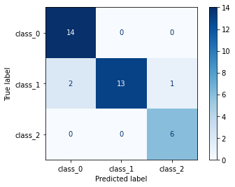

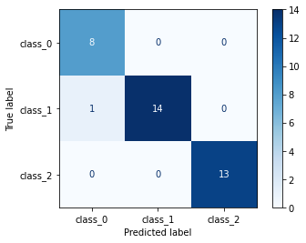

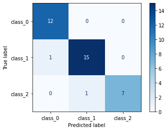

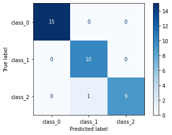

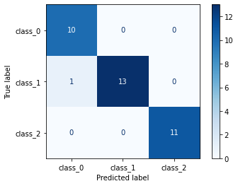

```python
from sklearn.metrics import ConfusionMatrixDisplay
import pandas as pd

# clean data summary results
print('CLEAN')
fold = 1
for cm, prec, recall in zip(confusion_matrices, precisions, recalls):
    cmp = ConfusionMatrixDisplay(cm, display_labels=wine.target_names)
    cmp.plot(cmap=plt.cm.Blues)
    print('Fold %i Precision: ' % fold, np.round(prec, 2),
         'Recall: ', np.round(recall, 2))
    fold += 1
```

```
NOISY
Fold 1 Precision:  [0.88 1.   0.86] Recall:  [1.   0.81 1.  ]
Fold 2 Precision:  [0.78 0.87 1.  ] Recall:  [0.88 0.87 0.92]
Fold 3 Precision:  [0.86 1.   1.  ] Recall:  [1.   0.88 1.  ]
Fold 4 Precision:  [0.88 1.   1.  ] Recall:  [1.  0.9 0.9]
Fold 5 Precision:  [0.91 1.   1.  ] Recall:  [1.   0.93 1.  ]
```

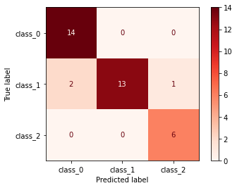

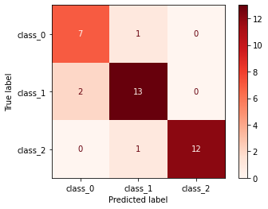

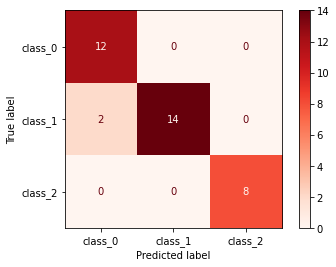

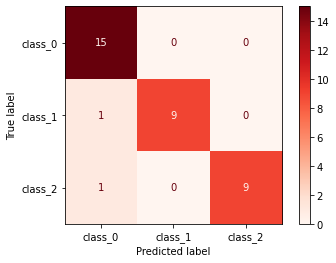

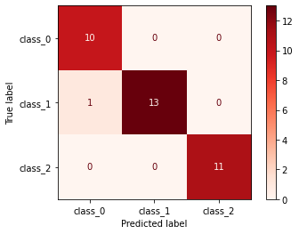

```python
print('NOISY')
# clean data summary results
fold = 1
for cm, prec, recall in zip(confusion_matrices_noise, precisions_noise, recalls_noise):
    cmp = ConfusionMatrixDisplay(cm, display_labels=wine.target_names)
    cmp.plot(cmap=plt.cm.Reds)
    print('Fold %i Precision: ' % fold, np.round(prec, 2),
         'Recall: ', np.round(recall, 2))
    fold += 1
```

## 6. More questions

Now answer the following questions as fully as you can. The answers should be based on your implementation above. Write your answers in the Markdown cells below each question.

### Q3. Influence of noise

Do the best parameters change when noise is added to the data? Can you say that one parameter choice is better regardless of the data used?

Answer: Yes. Based on my implementation above, the best parameters change when I added noise to the data.

For the parameter choice of distance metric, I can say that the euclidean is almost the best metric for my KNN classifier algorithm regardless of the data used. This is because euclidean was selected as a best parameter by nested validation every time for clean data and almost for noisy data, as you can see from 5. Summary of results.

However, for the parameter choice of k, the number of neighbors, I cannot say that one number is always better because the summary of results shows that the best k changes depending on the fold and noise to the data.

### Q4. Tie break

Assume that you have selected the number of neighbours to be an even number, e.g., 2. For one of the neighbours, the suggested class is 1, and for the other neighbour the suggested class is 2. How would you break the tie? Write example pseudocode that does this.

Answer:

I would break the tie by preparing a probability table and use it in such a situation, and choose a label based on the probability.

Algorithm is as follows:

1. In myKNN() function, build a probability table which is a dictionary of probabilities for each class
2. Pass it to predict() function and predict a label depending on the number of k and the frequency counts of classes

Pseudocode is as follows:

```
def mykNN(X, y, X_, n_neighbors, metric):

    create a list to store y_pred

    build a probability table

    for i in range(X_.shape[0]):

        get the distance list, the distance from Xi to every data point in X, along with y

        sort by distance column

        get n nearest neighbors

        label = predict(n_nearest_neighbors, probability_table)

        y_pred[i] = label

    return y_pred


def predict(n_nearest_neighbors, prob_table):

    create a list of bin count, the frequency count of each class

    if k is even and the frequency counts are same:

        choose the label with max probability

    else:
        choose the most frequent label within the neighbors

    return label


def bulld_prob_table(y):

    calculate a probability for each class

    return dictionary { class name : probability }
```

Please also see the functions myKNN(), predict(), and bulld_prob_table() in the earlier cells for my implementation in detail.

### Q5. Beyond Wine

If you were to run your k-nn algorithm on a new dataset (e.g., the breast cancer dataset, or Iris), what considerations would you need to take into consideration? Outline any changes that might be needed to your code.

Answer:

If I were to run myKNN algorithm on a new dataset, breast cancer dataset for example, I would need to take into account the following list of considerations.

- Tie break method:

  In the wine dataset, I selected the label with maximum probability to break the tie because there are multiple classes and the subject is wine. However, it might not be appropriate for the binary target of breast cancer data and I may want to consider more sophisticated way of tie break rule because the subject in this case is human and a false positive could result a false operation.
- Prediction method:

  In the wine dataset, I selected the most frequent label within the neighbors when tie break rule is not applied. However, it might also not be appropriate for the breast cancer case in the same reason I sated above. For example, I might need to consider implementing probabilistic 'weight' as an additional parameter which can be calculated per data point in advance, and take it into consideration when in prediction.
- Choice of features for X:

  There would be different types of features in a different dataset, and I would need to consider their correlations each other.

```python
breast_cancer=datasets.load_breast_cancer()
df_breast_cancer = pd.DataFrame(breast_cancer.data, columns = breast_cancer.feature_names )
df_breast_cancer.head()
```

|  | mean radius | mean texture | mean perimeter | mean area | mean smoothness | mean compactness | mean concavity | mean concave points | mean symmetry | mean fractal dimension | ... | worst radius | worst texture | worst perimeter | worst area | worst smoothness | worst compactness | worst concavity | worst concave points | worst symmetry | worst fractal dimension |
| --- | --- | --- | --- | --- | --- | --- | --- | --- | --- | --- | --- | --- | --- | --- | --- | --- | --- | --- | --- | --- | --- |
| 0 | 17.99 | 10.38 | 122.80 | 1001.0 | 0.11840 | 0.27760 | 0.3001 | 0.14710 | 0.2419 | 0.07871 | ... | 25.38 | 17.33 | 184.60 | 2019.0 | 0.1622 | 0.6656 | 0.7119 | 0.2654 | 0.4601 | 0.11890 |
| 1 | 20.57 | 17.77 | 132.90 | 1326.0 | 0.08474 | 0.07864 | 0.0869 | 0.07017 | 0.1812 | 0.05667 | ... | 24.99 | 23.41 | 158.80 | 1956.0 | 0.1238 | 0.1866 | 0.2416 | 0.1860 | 0.2750 | 0.08902 |
| 2 | 19.69 | 21.25 | 130.00 | 1203.0 | 0.10960 | 0.15990 | 0.1974 | 0.12790 | 0.2069 | 0.05999 | ... | 23.57 | 25.53 | 152.50 | 1709.0 | 0.1444 | 0.4245 | 0.4504 | 0.2430 | 0.3613 | 0.08758 |
| 3 | 11.42 | 20.38 | 77.58 | 386.1 | 0.14250 | 0.28390 | 0.2414 | 0.10520 | 0.2597 | 0.09744 | ... | 14.91 | 26.50 | 98.87 | 567.7 | 0.2098 | 0.8663 | 0.6869 | 0.2575 | 0.6638 | 0.17300 |
| 4 | 20.29 | 14.34 | 135.10 | 1297.0 | 0.10030 | 0.13280 | 0.1980 | 0.10430 | 0.1809 | 0.05883 | ... | 22.54 | 16.67 | 152.20 | 1575.0 | 0.1374 | 0.2050 | 0.4000 | 0.1625 | 0.2364 | 0.07678 |

5 rows × 30 columns